# Risk Factor Analysis

## Outcome Variable

**Outcome Variable:** wast_rec90d

## Predictor Variables

**Intervention Variable:** mwtkg

**Adjustment Set:**

unadjusted

## Stratifying Variables

The analysis was stratified on these variable(s):

- agecat
- studyid
- country

## Data Summary

| agecat | studyid | country | mwtkg | wast_rec90d | n_cell | n | outcome_variable |
| --- | --- | --- | --- | --- | --- | --- | --- |
| 0-24 months | ki0047075b-MAL-ED | BANGLADESH | >=58 kg | 0 | 3 | 122 | wast_rec90d |
| 0-24 months | ki0047075b-MAL-ED | BANGLADESH | >=58 kg | 1 | 9 | 122 | wast_rec90d |
| 0-24 months | ki0047075b-MAL-ED | BANGLADESH | <52 kg | 0 | 35 | 122 | wast_rec90d |
| 0-24 months | ki0047075b-MAL-ED | BANGLADESH | <52 kg | 1 | 59 | 122 | wast_rec90d |
| 0-24 months | ki0047075b-MAL-ED | BANGLADESH | [52-58) kg | 0 | 5 | 122 | wast_rec90d |
| 0-24 months | ki0047075b-MAL-ED | BANGLADESH | [52-58) kg | 1 | 11 | 122 | wast_rec90d |
| 0-24 months | ki0047075b-MAL-ED | BRAZIL | >=58 kg | 0 | 4 | 23 | wast_rec90d |
| 0-24 months | ki0047075b-MAL-ED | BRAZIL | >=58 kg | 1 | 8 | 23 | wast_rec90d |
| 0-24 months | ki0047075b-MAL-ED | BRAZIL | <52 kg | 0 | 0 | 23 | wast_rec90d |
| 0-24 months | ki0047075b-MAL-ED | BRAZIL | <52 kg | 1 | 2 | 23 | wast_rec90d |
| 0-24 months | ki0047075b-MAL-ED | BRAZIL | [52-58) kg | 0 | 2 | 23 | wast_rec90d |
| 0-24 months | ki0047075b-MAL-ED | BRAZIL | [52-58) kg | 1 | 7 | 23 | wast_rec90d |
| 0-24 months | ki0047075b-MAL-ED | INDIA | >=58 kg | 0 | 5 | 178 | wast_rec90d |
| 0-24 months | ki0047075b-MAL-ED | INDIA | >=58 kg | 1 | 9 | 178 | wast_rec90d |
| 0-24 months | ki0047075b-MAL-ED | INDIA | <52 kg | 0 | 54 | 178 | wast_rec90d |
| 0-24 months | ki0047075b-MAL-ED | INDIA | <52 kg | 1 | 81 | 178 | wast_rec90d |
| 0-24 months | ki0047075b-MAL-ED | INDIA | [52-58) kg | 0 | 11 | 178 | wast_rec90d |
| 0-24 months | ki0047075b-MAL-ED | INDIA | [52-58) kg | 1 | 18 | 178 | wast_rec90d |
| 0-24 months | ki0047075b-MAL-ED | NEPAL | >=58 kg | 0 | 2 | 98 | wast_rec90d |
| 0-24 months | ki0047075b-MAL-ED | NEPAL | >=58 kg | 1 | 16 | 98 | wast_rec90d |
| 0-24 months | ki0047075b-MAL-ED | NEPAL | <52 kg | 0 | 13 | 98 | wast_rec90d |
| 0-24 months | ki0047075b-MAL-ED | NEPAL | <52 kg | 1 | 38 | 98 | wast_rec90d |
| 0-24 months | ki0047075b-MAL-ED | NEPAL | [52-58) kg | 0 | 5 | 98 | wast_rec90d |
| 0-24 months | ki0047075b-MAL-ED | NEPAL | [52-58) kg | 1 | 24 | 98 | wast_rec90d |
| 0-24 months | ki0047075b-MAL-ED | PERU | >=58 kg | 0 | 1 | 35 | wast_rec90d |
| 0-24 months | ki0047075b-MAL-ED | PERU | >=58 kg | 1 | 8 | 35 | wast_rec90d |
| 0-24 months | ki0047075b-MAL-ED | PERU | <52 kg | 0 | 5 | 35 | wast_rec90d |
| 0-24 months | ki0047075b-MAL-ED | PERU | <52 kg | 1 | 15 | 35 | wast_rec90d |
| 0-24 months | ki0047075b-MAL-ED | PERU | [52-58) kg | 0 | 0 | 35 | wast_rec90d |
| 0-24 months | ki0047075b-MAL-ED | PERU | [52-58) kg | 1 | 6 | 35 | wast_rec90d |

[output cut: 270 more lines]

The following strata were considered:

- agecat: 0-24 months, studyid: ki0047075b-MAL-ED, country: BANGLADESH
- agecat: 0-24 months, studyid: ki0047075b-MAL-ED, country: BRAZIL
- agecat: 0-24 months, studyid: ki0047075b-MAL-ED, country: INDIA
- agecat: 0-24 months, studyid: ki0047075b-MAL-ED, country: NEPAL
- agecat: 0-24 months, studyid: ki0047075b-MAL-ED, country: PERU
- agecat: 0-24 months, studyid: ki0047075b-MAL-ED, country: SOUTH AFRICA
- agecat: 0-24 months, studyid: ki0047075b-MAL-ED, country: TANZANIA, UNITED REPUBLIC OF
- agecat: 0-24 months, studyid: ki1000304b-SAS-CompFeed, country: INDIA
- agecat: 0-24 months, studyid: ki1017093-NIH-Birth, country: BANGLADESH
- agecat: 0-24 months, studyid: ki1017093b-PROVIDE, country: BANGLADESH
- agecat: 0-24 months, studyid: ki1017093c-NIH-Crypto, country: BANGLADESH
- agecat: 0-24 months, studyid: ki1066203-TanzaniaChild2, country: TANZANIA, UNITED REPUBLIC OF
- agecat: 0-24 months, studyid: ki1112895-iLiNS-Zinc, country: BURKINA FASO
- agecat: 0-24 months, studyid: ki1119695-PROBIT, country: BELARUS
- agecat: 0-24 months, studyid: ki1126311-ZVITAMBO, country: ZIMBABWE
- agecat: 0-24 months, studyid: ki1148112-LCNI-5, country: MALAWI
- agecat: 0-24 months, studyid: kiGH5241-JiVitA-3, country: BANGLADESH
- agecat: 0-6 months, studyid: ki0047075b-MAL-ED, country: BANGLADESH
- agecat: 0-6 months, studyid: ki0047075b-MAL-ED, country: BRAZIL
- agecat: 0-6 months, studyid: ki0047075b-MAL-ED, country: INDIA
- agecat: 0-6 months, studyid: ki0047075b-MAL-ED, country: NEPAL
- agecat: 0-6 months, studyid: ki0047075b-MAL-ED, country: PERU
- agecat: 0-6 months, studyid: ki0047075b-MAL-ED, country: SOUTH AFRICA
- agecat: 0-6 months, studyid: ki0047075b-MAL-ED, country: TANZANIA, UNITED REPUBLIC OF
- agecat: 0-6 months, studyid: ki1000304b-SAS-CompFeed, country: INDIA
- agecat: 0-6 months, studyid: ki1017093-NIH-Birth, country: BANGLADESH
- agecat: 0-6 months, studyid: ki1017093b-PROVIDE, country: BANGLADESH
- agecat: 0-6 months, studyid: ki1017093c-NIH-Crypto, country: BANGLADESH
- agecat: 0-6 months, studyid: ki1066203-TanzaniaChild2, country: TANZANIA, UNITED REPUBLIC OF
- agecat: 0-6 months, studyid: ki1119695-PROBIT, country: BELARUS
- agecat: 0-6 months, studyid: ki1126311-ZVITAMBO, country: ZIMBABWE
- agecat: 0-6 months, studyid: ki1148112-LCNI-5, country: MALAWI
- agecat: 0-6 months, studyid: kiGH5241-JiVitA-3, country: BANGLADESH
- agecat: 6-24 months, studyid: ki0047075b-MAL-ED, country: BANGLADESH
- agecat: 6-24 months, studyid: ki0047075b-MAL-ED, country: BRAZIL
- agecat: 6-24 months, studyid: ki0047075b-MAL-ED, country: INDIA
- agecat: 6-24 months, studyid: ki0047075b-MAL-ED, country: NEPAL
- agecat: 6-24 months, studyid: ki0047075b-MAL-ED, country: PERU
- agecat: 6-24 months, studyid: ki0047075b-MAL-ED, country: SOUTH AFRICA
- agecat: 6-24 months, studyid: ki0047075b-MAL-ED, country: TANZANIA, UNITED REPUBLIC OF
- agecat: 6-24 months, studyid: ki1000304b-SAS-CompFeed, country: INDIA
- agecat: 6-24 months, studyid: ki1017093-NIH-Birth, country: BANGLADESH
- agecat: 6-24 months, studyid: ki1017093b-PROVIDE, country: BANGLADESH
- agecat: 6-24 months, studyid: ki1017093c-NIH-Crypto, country: BANGLADESH
- agecat: 6-24 months, studyid: ki1066203-TanzaniaChild2, country: TANZANIA, UNITED REPUBLIC OF
- agecat: 6-24 months, studyid: ki1112895-iLiNS-Zinc, country: BURKINA FASO
- agecat: 6-24 months, studyid: ki1119695-PROBIT, country: BELARUS
- agecat: 6-24 months, studyid: ki1126311-ZVITAMBO, country: ZIMBABWE
- agecat: 6-24 months, studyid: ki1148112-LCNI-5, country: MALAWI
- agecat: 6-24 months, studyid: kiGH5241-JiVitA-3, country: BANGLADESH

### Dropped Strata

Some strata were dropped due to rare outcomes:

- agecat: 0-24 months, studyid: ki0047075b-MAL-ED, country: BANGLADESH
- agecat: 0-24 months, studyid: ki0047075b-MAL-ED, country: BRAZIL
- agecat: 0-24 months, studyid: ki0047075b-MAL-ED, country: NEPAL
- agecat: 0-24 months, studyid: ki0047075b-MAL-ED, country: PERU
- agecat: 0-24 months, studyid: ki0047075b-MAL-ED, country: SOUTH AFRICA
- agecat: 0-24 months, studyid: ki0047075b-MAL-ED, country: TANZANIA, UNITED REPUBLIC OF
- agecat: 0-24 months, studyid: ki1148112-LCNI-5, country: MALAWI
- agecat: 0-6 months, studyid: ki0047075b-MAL-ED, country: BANGLADESH
- agecat: 0-6 months, studyid: ki0047075b-MAL-ED, country: BRAZIL
- agecat: 0-6 months, studyid: ki0047075b-MAL-ED, country: INDIA
- agecat: 0-6 months, studyid: ki0047075b-MAL-ED, country: NEPAL
- agecat: 0-6 months, studyid: ki0047075b-MAL-ED, country: PERU
- agecat: 0-6 months, studyid: ki0047075b-MAL-ED, country: SOUTH AFRICA
- agecat: 0-6 months, studyid: ki0047075b-MAL-ED, country: TANZANIA, UNITED REPUBLIC OF
- agecat: 0-6 months, studyid: ki1017093b-PROVIDE, country: BANGLADESH
- agecat: 0-6 months, studyid: ki1017093c-NIH-Crypto, country: BANGLADESH
- agecat: 0-6 months, studyid: ki1148112-LCNI-5, country: MALAWI
- agecat: 6-24 months, studyid: ki0047075b-MAL-ED, country: BANGLADESH
- agecat: 6-24 months, studyid: ki0047075b-MAL-ED, country: BRAZIL
- agecat: 6-24 months, studyid: ki0047075b-MAL-ED, country: INDIA
- agecat: 6-24 months, studyid: ki0047075b-MAL-ED, country: NEPAL
- agecat: 6-24 months, studyid: ki0047075b-MAL-ED, country: PERU
- agecat: 6-24 months, studyid: ki0047075b-MAL-ED, country: SOUTH AFRICA
- agecat: 6-24 months, studyid: ki0047075b-MAL-ED, country: TANZANIA, UNITED REPUBLIC OF
- agecat: 6-24 months, studyid: ki1017093b-PROVIDE, country: BANGLADESH
- agecat: 6-24 months, studyid: ki1017093c-NIH-Crypto, country: BANGLADESH
- agecat: 6-24 months, studyid: ki1119695-PROBIT, country: BELARUS
- agecat: 6-24 months, studyid: ki1148112-LCNI-5, country: MALAWI
- agecat: 6-24 months, studyid: kiGH5241-JiVitA-3, country: BANGLADESH

## Methods Detail

We’re interested in the causal parameters $E[Y_a]$ for all values of $a \in \mathcal{A}$. These parameters represent the mean outcome if, possibly contrary to fact, we intervened to set all units to have $A=a$. Under the randomization and positivity assumptions, these are identified by the statistical parameters $\psi_a=E_W[E_{Y|A,W}(Y|A=a,W)]$. In addition, we’re interested in the mean of $Y$, $E[Y]$ under no intervention (the observed mean). We will estimate these parameters by using SuperLearner to fit the relevant likelihood factors – $E_{Y|A,W}(Y|A=a,W)$ and $p(A=a|W)$, and then updating our likelihood fit using a joint TMLE.

For unadjusted analyses ($W=\{\}$), initial likelihoods were estimated using Lrnr_glm to estimate the simple $E(Y|A)$ and Lrnr_mean to estimate $p(A)$. For adjusted analyses, a small library containing Lrnr_glmnet, Lrnr_xgboost, and Lrnr_mean was used.

Having estimated these parameters, we will then use the delta method to estimate relative risks and attributable risks relative to a prespecified baseline level of $A$.

# Results Detail

## Results Plots

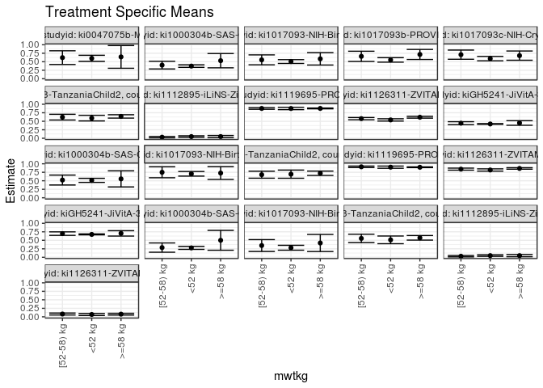

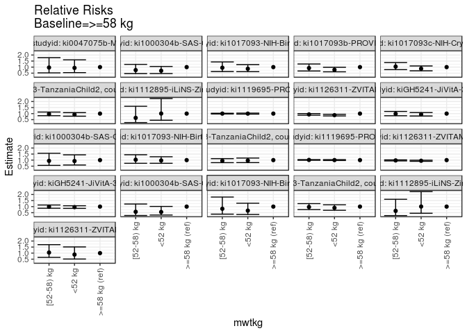

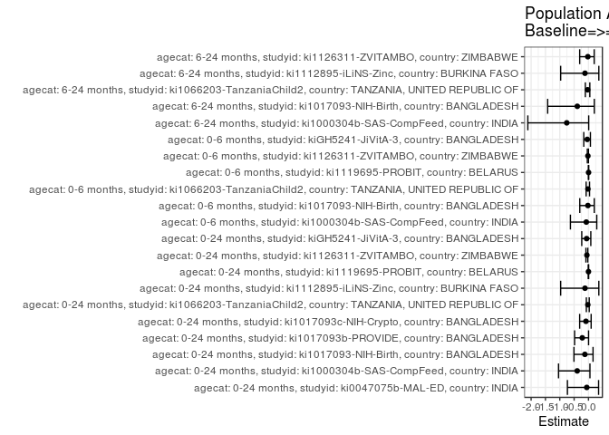

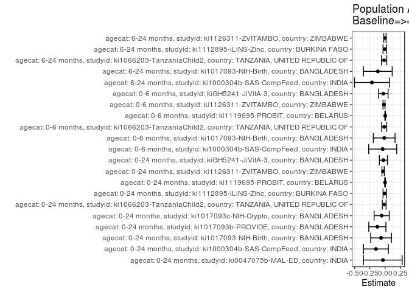

## Results Table

### Parameter: TSM

| agecat | studyid | country | intervention_level | baseline_level | estimate | ci_lower | ci_upper |
| --- | --- | --- | --- | --- | --- | --- | --- |
| 0-24 months | ki0047075b-MAL-ED | INDIA | >=58 kg | NA | 0.6428571 | 0.3090040 | 0.9767102 |
| 0-24 months | ki0047075b-MAL-ED | INDIA | <52 kg | NA | 0.6000000 | 0.5104195 | 0.6895805 |
| 0-24 months | ki0047075b-MAL-ED | INDIA | [52-58) kg | NA | 0.6206897 | 0.4196644 | 0.8217149 |
| 0-24 months | ki1000304b-SAS-CompFeed | INDIA | >=58 kg | NA | 0.5312500 | 0.3215651 | 0.7409349 |
| 0-24 months | ki1000304b-SAS-CompFeed | INDIA | <52 kg | NA | 0.3718887 | 0.3347492 | 0.4090282 |
| 0-24 months | ki1000304b-SAS-CompFeed | INDIA | [52-58) kg | NA | 0.4000000 | 0.2871107 | 0.5128893 |
| 0-24 months | ki1017093-NIH-Birth | BANGLADESH | >=58 kg | NA | 0.5853658 | 0.4034903 | 0.7672414 |
| 0-24 months | ki1017093-NIH-Birth | BANGLADESH | <52 kg | NA | 0.5061350 | 0.4500094 | 0.5622605 |
| 0-24 months | ki1017093-NIH-Birth | BANGLADESH | [52-58) kg | NA | 0.5555556 | 0.4097932 | 0.7013179 |
| 0-24 months | ki1017093b-PROVIDE | BANGLADESH | >=58 kg | NA | 0.7142857 | 0.5668399 | 0.8617315 |
| 0-24 months | ki1017093b-PROVIDE | BANGLADESH | <52 kg | NA | 0.5535714 | 0.4873000 | 0.6198429 |
| 0-24 months | ki1017093b-PROVIDE | BANGLADESH | [52-58) kg | NA | 0.6590909 | 0.5087422 | 0.8094396 |
| 0-24 months | ki1017093c-NIH-Crypto | BANGLADESH | >=58 kg | NA | 0.6800000 | 0.5438618 | 0.8161382 |
| 0-24 months | ki1017093c-NIH-Crypto | BANGLADESH | <52 kg | NA | 0.5924171 | 0.5270766 | 0.6577576 |
| 0-24 months | ki1017093c-NIH-Crypto | BANGLADESH | [52-58) kg | NA | 0.7083333 | 0.5732108 | 0.8434559 |
| 0-24 months | ki1066203-TanzaniaChild2 | TANZANIA, UNITED REPUBLIC OF | >=58 kg | NA | 0.6426859 | 0.5935011 | 0.6918706 |
| 0-24 months | ki1066203-TanzaniaChild2 | TANZANIA, UNITED REPUBLIC OF | <52 kg | NA | 0.5925926 | 0.5100432 | 0.6751420 |
| 0-24 months | ki1066203-TanzaniaChild2 | TANZANIA, UNITED REPUBLIC OF | [52-58) kg | NA | 0.6209150 | 0.5369579 | 0.7048722 |
| 0-24 months | ki1112895-iLiNS-Zinc | BURKINA FASO | >=58 kg | NA | 0.0494505 | 0.0167815 | 0.0821196 |
| 0-24 months | ki1112895-iLiNS-Zinc | BURKINA FASO | <52 kg | NA | 0.0497238 | 0.0270395 | 0.0724080 |
| 0-24 months | ki1112895-iLiNS-Zinc | BURKINA FASO | [52-58) kg | NA | 0.0320000 | 0.0119568 | 0.0520432 |
| 0-24 months | ki1119695-PROBIT | BELARUS | >=58 kg | NA | 0.8774880 | 0.8656644 | 0.8893116 |
| 0-24 months | ki1119695-PROBIT | BELARUS | <52 kg | NA | 0.8757225 | 0.8414450 | 0.9100001 |
| 0-24 months | ki1119695-PROBIT | BELARUS | [52-58) kg | NA | 0.8771186 | 0.8533731 | 0.9008642 |
| 0-24 months | ki1126311-ZVITAMBO | ZIMBABWE | >=58 kg | NA | 0.6184305 | 0.5922315 | 0.6446295 |
| 0-24 months | ki1126311-ZVITAMBO | ZIMBABWE | <52 kg | NA | 0.5396825 | 0.5059811 | 0.5733839 |
| 0-24 months | ki1126311-ZVITAMBO | ZIMBABWE | [52-58) kg | NA | 0.5770609 | 0.5439802 | 0.6101416 |
| 0-24 months | kiGH5241-JiVitA-3 | BANGLADESH | >=58 kg | NA | 0.4497041 | 0.3825662 | 0.5168421 |
| 0-24 months | kiGH5241-JiVitA-3 | BANGLADESH | <52 kg | NA | 0.4202752 | 0.4086476 | 0.4319028 |
| 0-24 months | kiGH5241-JiVitA-3 | BANGLADESH | [52-58) kg | NA | 0.4426230 | 0.3981416 | 0.4871043 |
| 0-6 months | ki1000304b-SAS-CompFeed | INDIA | >=58 kg | NA | 0.5555556 | 0.3186642 | 0.7924469 |
| 0-6 months | ki1000304b-SAS-CompFeed | INDIA | <52 kg | NA | 0.5127273 | 0.4532019 | 0.5722526 |
| 0-6 months | ki1000304b-SAS-CompFeed | INDIA | [52-58) kg | NA | 0.5217391 | 0.3760549 | 0.6674233 |
| 0-6 months | ki1017093-NIH-Birth | BANGLADESH | >=58 kg | NA | 0.7272727 | 0.5399105 | 0.9146349 |
| 0-6 months | ki1017093-NIH-Birth | BANGLADESH | <52 kg | NA | 0.7052023 | 0.6373168 | 0.7730878 |
| 0-6 months | ki1017093-NIH-Birth | BANGLADESH | [52-58) kg | NA | 0.7500000 | 0.5885262 | 0.9114738 |
| 0-6 months | ki1066203-TanzaniaChild2 | TANZANIA, UNITED REPUBLIC OF | >=58 kg | NA | 0.7208122 | 0.6570635 | 0.7845609 |
| 0-6 months | ki1066203-TanzaniaChild2 | TANZANIA, UNITED REPUBLIC OF | <52 kg | NA | 0.6949153 | 0.5752008 | 0.8146297 |
| 0-6 months | ki1066203-TanzaniaChild2 | TANZANIA, UNITED REPUBLIC OF | [52-58) kg | NA | 0.6790123 | 0.5766082 | 0.7814165 |
| 0-6 months | ki1119695-PROBIT | BELARUS | >=58 kg | NA | 0.8977999 | 0.8865084 | 0.9090913 |
| 0-6 months | ki1119695-PROBIT | BELARUS | <52 kg | NA | 0.9006024 | 0.8684453 | 0.9327595 |
| 0-6 months | ki1119695-PROBIT | BELARUS | [52-58) kg | NA | 0.9111111 | 0.8895366 | 0.9326856 |
| 0-6 months | ki1126311-ZVITAMBO | ZIMBABWE | >=58 kg | NA | 0.8629707 | 0.8411232 | 0.8848182 |
| 0-6 months | ki1126311-ZVITAMBO | ZIMBABWE | <52 kg | NA | 0.8174757 | 0.7842031 | 0.8507484 |
| 0-6 months | ki1126311-ZVITAMBO | ZIMBABWE | [52-58) kg | NA | 0.8422018 | 0.8120982 | 0.8723055 |
| 0-6 months | kiGH5241-JiVitA-3 | BANGLADESH | >=58 kg | NA | 0.7037037 | 0.6249922 | 0.7824152 |
| 0-6 months | kiGH5241-JiVitA-3 | BANGLADESH | <52 kg | NA | 0.6731617 | 0.6591563 | 0.6871670 |
| 0-6 months | kiGH5241-JiVitA-3 | BANGLADESH | [52-58) kg | NA | 0.6967742 | 0.6457904 | 0.7477580 |
| 6-24 months | ki1000304b-SAS-CompFeed | INDIA | >=58 kg | NA | 0.5000000 | 0.2080230 | 0.7919770 |
| 6-24 months | ki1000304b-SAS-CompFeed | INDIA | <52 kg | NA | 0.2769608 | 0.2328732 | 0.3210483 |
| 6-24 months | ki1000304b-SAS-CompFeed | INDIA | [52-58) kg | NA | 0.2857143 | 0.1492017 | 0.4222269 |
| 6-24 months | ki1017093-NIH-Birth | BANGLADESH | >=58 kg | NA | 0.4210526 | 0.1702652 | 0.6718400 |
| 6-24 months | ki1017093-NIH-Birth | BANGLADESH | <52 kg | NA | 0.2810458 | 0.2089924 | 0.3530991 |
| 6-24 months | ki1017093-NIH-Birth | BANGLADESH | [52-58) kg | NA | 0.3461538 | 0.1723455 | 0.5199622 |
| 6-24 months | ki1066203-TanzaniaChild2 | TANZANIA, UNITED REPUBLIC OF | >=58 kg | NA | 0.5727273 | 0.5052784 | 0.6401762 |
| 6-24 months | ki1066203-TanzaniaChild2 | TANZANIA, UNITED REPUBLIC OF | <52 kg | NA | 0.5131579 | 0.3996590 | 0.6266568 |
| 6-24 months | ki1066203-TanzaniaChild2 | TANZANIA, UNITED REPUBLIC OF | [52-58) kg | NA | 0.5555556 | 0.4322631 | 0.6788480 |
| 6-24 months | ki1112895-iLiNS-Zinc | BURKINA FASO | >=58 kg | NA | 0.0494505 | 0.0167815 | 0.0821196 |
| 6-24 months | ki1112895-iLiNS-Zinc | BURKINA FASO | <52 kg | NA | 0.0497238 | 0.0270395 | 0.0724080 |
| 6-24 months | ki1112895-iLiNS-Zinc | BURKINA FASO | [52-58) kg | NA | 0.0320000 | 0.0119568 | 0.0520432 |
| 6-24 months | ki1126311-ZVITAMBO | ZIMBABWE | >=58 kg | NA | 0.0785219 | 0.0526146 | 0.1044293 |
| 6-24 months | ki1126311-ZVITAMBO | ZIMBABWE | <52 kg | NA | 0.0690789 | 0.0394268 | 0.0987311 |
| 6-24 months | ki1126311-ZVITAMBO | ZIMBABWE | [52-58) kg | NA | 0.0821918 | 0.0532147 | 0.1111688 |

### Parameter: E(Y)

| agecat | studyid | country | intervention_level | baseline_level | estimate | ci_lower | ci_upper |
| --- | --- | --- | --- | --- | --- | --- | --- |
| 0-24 months | ki0047075b-MAL-ED | INDIA | NA | NA | 0.6067416 | 0.5268346 | 0.6866486 |
| 0-24 months | ki1000304b-SAS-CompFeed | INDIA | NA | NA | 0.3814815 | 0.3463355 | 0.4166275 |
| 0-24 months | ki1017093-NIH-Birth | BANGLADESH | NA | NA | 0.5201900 | 0.4695846 | 0.5707955 |
| 0-24 months | ki1017093b-PROVIDE | BANGLADESH | NA | NA | 0.5874587 | 0.5306185 | 0.6442990 |
| 0-24 months | ki1017093c-NIH-Crypto | BANGLADESH | NA | NA | 0.6245955 | 0.5705077 | 0.6786833 |
| 0-24 months | ki1066203-TanzaniaChild2 | TANZANIA, UNITED REPUBLIC OF | NA | NA | 0.6283688 | 0.5905321 | 0.6662055 |
| 0-24 months | ki1112895-iLiNS-Zinc | BURKINA FASO | NA | NA | 0.0440806 | 0.0298222 | 0.0583390 |
| 0-24 months | ki1119695-PROBIT | BELARUS | NA | NA | 0.8772681 | 0.8671551 | 0.8873812 |
| 0-24 months | ki1126311-ZVITAMBO | ZIMBABWE | NA | NA | 0.5858785 | 0.5683064 | 0.6034506 |
| 0-24 months | kiGH5241-JiVitA-3 | BANGLADESH | NA | NA | 0.4223750 | 0.4112477 | 0.4335024 |
| 0-6 months | ki1000304b-SAS-CompFeed | INDIA | NA | NA | 0.5162242 | 0.4625356 | 0.5699128 |
| 0-6 months | ki1017093-NIH-Birth | BANGLADESH | NA | NA | 0.7130045 | 0.6535890 | 0.7724200 |
| 0-6 months | ki1066203-TanzaniaChild2 | TANZANIA, UNITED REPUBLIC OF | NA | NA | 0.7062315 | 0.6568751 | 0.7555878 |
| 0-6 months | ki1119695-PROBIT | BELARUS | NA | NA | 0.9003922 | 0.8908257 | 0.9099586 |
| 0-6 months | ki1126311-ZVITAMBO | ZIMBABWE | NA | NA | 0.8457341 | 0.8300360 | 0.8614323 |
| 0-6 months | kiGH5241-JiVitA-3 | BANGLADESH | NA | NA | 0.6754071 | 0.6620619 | 0.6887522 |
| 6-24 months | ki1000304b-SAS-CompFeed | INDIA | NA | NA | 0.2845011 | 0.2426711 | 0.3263311 |
| 6-24 months | ki1017093-NIH-Birth | BANGLADESH | NA | NA | 0.3030303 | 0.2377927 | 0.3682679 |
| 6-24 months | ki1066203-TanzaniaChild2 | TANZANIA, UNITED REPUBLIC OF | NA | NA | 0.5570652 | 0.5044805 | 0.6096499 |
| 6-24 months | ki1112895-iLiNS-Zinc | BURKINA FASO | NA | NA | 0.0440806 | 0.0298222 | 0.0583390 |
| 6-24 months | ki1126311-ZVITAMBO | ZIMBABWE | NA | NA | 0.0767736 | 0.0605511 | 0.0929961 |

### Parameter: RR

| agecat | studyid | country | intervention_level | baseline_level | estimate | ci_lower | ci_upper |
| --- | --- | --- | --- | --- | --- | --- | --- |
| 0-24 months | ki0047075b-MAL-ED | INDIA | >=58 kg | >=58 kg | 1.0000000 | 1.0000000 | 1.0000000 |
| 0-24 months | ki0047075b-MAL-ED | INDIA | <52 kg | >=58 kg | 0.9333333 | 0.5436369 | 1.6023766 |
| 0-24 months | ki0047075b-MAL-ED | INDIA | [52-58) kg | >=58 kg | 0.9655172 | 0.5237016 | 1.7800664 |
| 0-24 months | ki1000304b-SAS-CompFeed | INDIA | >=58 kg | >=58 kg | 1.0000000 | 1.0000000 | 1.0000000 |
| 0-24 months | ki1000304b-SAS-CompFeed | INDIA | <52 kg | >=58 kg | 0.7000258 | 0.4659049 | 1.0517945 |
| 0-24 months | ki1000304b-SAS-CompFeed | INDIA | [52-58) kg | >=58 kg | 0.7529412 | 0.4634801 | 1.2231818 |
| 0-24 months | ki1017093-NIH-Birth | BANGLADESH | >=58 kg | >=58 kg | 1.0000000 | 1.0000000 | 1.0000000 |
| 0-24 months | ki1017093-NIH-Birth | BANGLADESH | <52 kg | >=58 kg | 0.8646472 | 0.6216696 | 1.2025920 |
| 0-24 months | ki1017093-NIH-Birth | BANGLADESH | [52-58) kg | >=58 kg | 0.9490741 | 0.6319417 | 1.4253557 |
| 0-24 months | ki1017093b-PROVIDE | BANGLADESH | >=58 kg | >=58 kg | 1.0000000 | 1.0000000 | 1.0000000 |
| 0-24 months | ki1017093b-PROVIDE | BANGLADESH | <52 kg | >=58 kg | 0.7750000 | 0.6103311 | 0.9840970 |
| 0-24 months | ki1017093b-PROVIDE | BANGLADESH | [52-58) kg | >=58 kg | 0.9227273 | 0.6782172 | 1.2553877 |
| 0-24 months | ki1017093c-NIH-Crypto | BANGLADESH | >=58 kg | >=58 kg | 1.0000000 | 1.0000000 | 1.0000000 |
| 0-24 months | ki1017093c-NIH-Crypto | BANGLADESH | <52 kg | >=58 kg | 0.8712016 | 0.6929653 | 1.0952817 |
| 0-24 months | ki1017093c-NIH-Crypto | BANGLADESH | [52-58) kg | >=58 kg | 1.0416667 | 0.7899610 | 1.3735735 |
| 0-24 months | ki1066203-TanzaniaChild2 | TANZANIA, UNITED REPUBLIC OF | >=58 kg | >=58 kg | 1.0000000 | 1.0000000 | 1.0000000 |
| 0-24 months | ki1066203-TanzaniaChild2 | TANZANIA, UNITED REPUBLIC OF | <52 kg | >=58 kg | 0.9220564 | 0.7865536 | 1.0809028 |
| 0-24 months | ki1066203-TanzaniaChild2 | TANZANIA, UNITED REPUBLIC OF | [52-58) kg | >=58 kg | 0.9661253 | 0.8270983 | 1.1285213 |
| 0-24 months | ki1112895-iLiNS-Zinc | BURKINA FASO | >=58 kg | >=58 kg | 1.0000000 | 1.0000000 | 1.0000000 |
| 0-24 months | ki1112895-iLiNS-Zinc | BURKINA FASO | <52 kg | >=58 kg | 1.0055249 | 0.4505247 | 2.2442281 |
| 0-24 months | ki1112895-iLiNS-Zinc | BURKINA FASO | [52-58) kg | >=58 kg | 0.6471111 | 0.2603826 | 1.6082211 |
| 0-24 months | ki1119695-PROBIT | BELARUS | >=58 kg | >=58 kg | 1.0000000 | 1.0000000 | 1.0000000 |
| 0-24 months | ki1119695-PROBIT | BELARUS | <52 kg | >=58 kg | 0.9979881 | 0.9575183 | 1.0401683 |
| 0-24 months | ki1119695-PROBIT | BELARUS | [52-58) kg | >=58 kg | 0.9995791 | 0.9698036 | 1.0302687 |
| 0-24 months | ki1126311-ZVITAMBO | ZIMBABWE | >=58 kg | >=58 kg | 1.0000000 | 1.0000000 | 1.0000000 |
| 0-24 months | ki1126311-ZVITAMBO | ZIMBABWE | <52 kg | >=58 kg | 0.8726648 | 0.8092217 | 0.9410818 |
| 0-24 months | ki1126311-ZVITAMBO | ZIMBABWE | [52-58) kg | >=58 kg | 0.9331055 | 0.8688888 | 1.0020683 |
| 0-24 months | kiGH5241-JiVitA-3 | BANGLADESH | >=58 kg | >=58 kg | 1.0000000 | 1.0000000 | 1.0000000 |
| 0-24 months | kiGH5241-JiVitA-3 | BANGLADESH | <52 kg | >=58 kg | 0.9345592 | 0.8029076 | 1.0877976 |
| 0-24 months | kiGH5241-JiVitA-3 | BANGLADESH | [52-58) kg | >=58 kg | 0.9842537 | 0.8221456 | 1.1783257 |
| 0-6 months | ki1000304b-SAS-CompFeed | INDIA | >=58 kg | >=58 kg | 1.0000000 | 1.0000000 | 1.0000000 |
| 0-6 months | ki1000304b-SAS-CompFeed | INDIA | <52 kg | >=58 kg | 0.9229091 | 0.5932432 | 1.4357707 |
| 0-6 months | ki1000304b-SAS-CompFeed | INDIA | [52-58) kg | >=58 kg | 0.9391304 | 0.5641157 | 1.5634487 |
| 0-6 months | ki1017093-NIH-Birth | BANGLADESH | >=58 kg | >=58 kg | 1.0000000 | 1.0000000 | 1.0000000 |
| 0-6 months | ki1017093-NIH-Birth | BANGLADESH | <52 kg | >=58 kg | 0.9696532 | 0.7365063 | 1.2766045 |
| 0-6 months | ki1017093-NIH-Birth | BANGLADESH | [52-58) kg | >=58 kg | 1.0312500 | 0.7371449 | 1.4426967 |
| 0-6 months | ki1066203-TanzaniaChild2 | TANZANIA, UNITED REPUBLIC OF | >=58 kg | >=58 kg | 1.0000000 | 1.0000000 | 1.0000000 |
| 0-6 months | ki1066203-TanzaniaChild2 | TANZANIA, UNITED REPUBLIC OF | <52 kg | >=58 kg | 0.9640726 | 0.7943424 | 1.1700696 |
| 0-6 months | ki1066203-TanzaniaChild2 | TANZANIA, UNITED REPUBLIC OF | [52-58) kg | >=58 kg | 0.9420101 | 0.7909114 | 1.1219753 |
| 0-6 months | ki1119695-PROBIT | BELARUS | >=58 kg | >=58 kg | 1.0000000 | 1.0000000 | 1.0000000 |
| 0-6 months | ki1119695-PROBIT | BELARUS | <52 kg | >=58 kg | 1.0031216 | 0.9658567 | 1.0418242 |
| 0-6 months | ki1119695-PROBIT | BELARUS | [52-58) kg | >=58 kg | 1.0148265 | 0.9879785 | 1.0424042 |
| 0-6 months | ki1126311-ZVITAMBO | ZIMBABWE | >=58 kg | >=58 kg | 1.0000000 | 1.0000000 | 1.0000000 |
| 0-6 months | ki1126311-ZVITAMBO | ZIMBABWE | <52 kg | >=58 kg | 0.9472810 | 0.9029461 | 0.9937927 |
| 0-6 months | ki1126311-ZVITAMBO | ZIMBABWE | [52-58) kg | >=58 kg | 0.9759333 | 0.9341087 | 1.0196306 |
| 0-6 months | kiGH5241-JiVitA-3 | BANGLADESH | >=58 kg | >=58 kg | 1.0000000 | 1.0000000 | 1.0000000 |
| 0-6 months | kiGH5241-JiVitA-3 | BANGLADESH | <52 kg | >=58 kg | 0.9565982 | 0.8537272 | 1.0718647 |
| 0-6 months | kiGH5241-JiVitA-3 | BANGLADESH | [52-58) kg | >=58 kg | 0.9901528 | 0.8662717 | 1.1317495 |
| 6-24 months | ki1000304b-SAS-CompFeed | INDIA | >=58 kg | >=58 kg | 1.0000000 | 1.0000000 | 1.0000000 |
| 6-24 months | ki1000304b-SAS-CompFeed | INDIA | <52 kg | >=58 kg | 0.5539216 | 0.3024033 | 1.0146354 |
| 6-24 months | ki1000304b-SAS-CompFeed | INDIA | [52-58) kg | >=58 kg | 0.5714286 | 0.2687084 | 1.2151857 |
| 6-24 months | ki1017093-NIH-Birth | BANGLADESH | >=58 kg | >=58 kg | 1.0000000 | 1.0000000 | 1.0000000 |
| 6-24 months | ki1017093-NIH-Birth | BANGLADESH | <52 kg | >=58 kg | 0.6674837 | 0.3488386 | 1.2771937 |
| 6-24 months | ki1017093-NIH-Birth | BANGLADESH | [52-58) kg | >=58 kg | 0.8221154 | 0.3772729 | 1.7914718 |
| 6-24 months | ki1066203-TanzaniaChild2 | TANZANIA, UNITED REPUBLIC OF | >=58 kg | >=58 kg | 1.0000000 | 1.0000000 | 1.0000000 |
| 6-24 months | ki1066203-TanzaniaChild2 | TANZANIA, UNITED REPUBLIC OF | <52 kg | >=58 kg | 0.8959900 | 0.6973883 | 1.1511493 |
| 6-24 months | ki1066203-TanzaniaChild2 | TANZANIA, UNITED REPUBLIC OF | [52-58) kg | >=58 kg | 0.9700176 | 0.7545103 | 1.2470793 |
| 6-24 months | ki1112895-iLiNS-Zinc | BURKINA FASO | >=58 kg | >=58 kg | 1.0000000 | 1.0000000 | 1.0000000 |
| 6-24 months | ki1112895-iLiNS-Zinc | BURKINA FASO | <52 kg | >=58 kg | 1.0055249 | 0.4505247 | 2.2442281 |
| 6-24 months | ki1112895-iLiNS-Zinc | BURKINA FASO | [52-58) kg | >=58 kg | 0.6471111 | 0.2603826 | 1.6082211 |
| 6-24 months | ki1126311-ZVITAMBO | ZIMBABWE | >=58 kg | >=58 kg | 1.0000000 | 1.0000000 | 1.0000000 |
| 6-24 months | ki1126311-ZVITAMBO | ZIMBABWE | <52 kg | >=58 kg | 0.8797407 | 0.5119502 | 1.5117558 |
| 6-24 months | ki1126311-ZVITAMBO | ZIMBABWE | [52-58) kg | >=58 kg | 1.0467365 | 0.6458518 | 1.6964531 |

### Parameter: PAR

| agecat | studyid | country | intervention_level | baseline_level | estimate | ci_lower | ci_upper |
| --- | --- | --- | --- | --- | --- | --- | --- |
| 0-24 months | ki0047075b-MAL-ED | INDIA | >=58 kg | NA | -0.0361156 | -0.3530819 | 0.2808508 |
| 0-24 months | ki1000304b-SAS-CompFeed | INDIA | >=58 kg | NA | -0.1497685 | -0.3540331 | 0.0544960 |
| 0-24 months | ki1017093-NIH-Birth | BANGLADESH | >=58 kg | NA | -0.0651758 | -0.2360244 | 0.1056728 |
| 0-24 months | ki1017093b-PROVIDE | BANGLADESH | >=58 kg | NA | -0.1268270 | -0.2674449 | 0.0137909 |
| 0-24 months | ki1017093c-NIH-Crypto | BANGLADESH | >=58 kg | NA | -0.0554045 | -0.1796536 | 0.0688445 |
| 0-24 months | ki1066203-TanzaniaChild2 | TANZANIA, UNITED REPUBLIC OF | >=58 kg | NA | -0.0143171 | -0.0457770 | 0.0171429 |
| 0-24 months | ki1112895-iLiNS-Zinc | BURKINA FASO | >=58 kg | NA | -0.0053699 | -0.0333220 | 0.0225821 |
| 0-24 months | ki1119695-PROBIT | BELARUS | >=58 kg | NA | -0.0002198 | -0.0062819 | 0.0058422 |
| 0-24 months | ki1126311-ZVITAMBO | ZIMBABWE | >=58 kg | NA | -0.0325520 | -0.0517329 | -0.0133712 |
| 0-24 months | kiGH5241-JiVitA-3 | BANGLADESH | >=58 kg | NA | -0.0273291 | -0.0937060 | 0.0390478 |
| 0-6 months | ki1000304b-SAS-CompFeed | INDIA | >=58 kg | NA | -0.0393314 | -0.2696368 | 0.1909741 |
| 0-6 months | ki1017093-NIH-Birth | BANGLADESH | >=58 kg | NA | -0.0142682 | -0.1923365 | 0.1638001 |
| 0-6 months | ki1066203-TanzaniaChild2 | TANZANIA, UNITED REPUBLIC OF | >=58 kg | NA | -0.0145807 | -0.0564284 | 0.0272669 |
| 0-6 months | ki1119695-PROBIT | BELARUS | >=58 kg | NA | 0.0025923 | -0.0029886 | 0.0081732 |
| 0-6 months | ki1126311-ZVITAMBO | ZIMBABWE | >=58 kg | NA | -0.0172366 | -0.0337002 | -0.0007730 |
| 0-6 months | kiGH5241-JiVitA-3 | BANGLADESH | >=58 kg | NA | -0.0282966 | -0.1061672 | 0.0495739 |
| 6-24 months | ki1000304b-SAS-CompFeed | INDIA | >=58 kg | NA | -0.2154989 | -0.5017372 | 0.0707393 |
| 6-24 months | ki1017093-NIH-Birth | BANGLADESH | >=58 kg | NA | -0.1180223 | -0.3533429 | 0.1172982 |
| 6-24 months | ki1066203-TanzaniaChild2 | TANZANIA, UNITED REPUBLIC OF | >=58 kg | NA | -0.0156621 | -0.0589910 | 0.0276669 |
| 6-24 months | ki1112895-iLiNS-Zinc | BURKINA FASO | >=58 kg | NA | -0.0053699 | -0.0333220 | 0.0225821 |
| 6-24 months | ki1126311-ZVITAMBO | ZIMBABWE | >=58 kg | NA | -0.0017484 | -0.0209707 | 0.0174739 |

### Parameter: PAF

| agecat | studyid | country | intervention_level | baseline_level | estimate | ci_lower | ci_upper |
| --- | --- | --- | --- | --- | --- | --- | --- |
| 0-24 months | ki0047075b-MAL-ED | INDIA | >=58 kg | NA | -0.0595238 | -0.7337052 | 0.3524904 |
| 0-24 months | ki1000304b-SAS-CompFeed | INDIA | >=58 kg | NA | -0.3925971 | -1.0436146 | 0.0510311 |
| 0-24 months | ki1017093-NIH-Birth | BANGLADESH | >=58 kg | NA | -0.1252923 | -0.5057292 | 0.1590235 |
| 0-24 months | ki1017093b-PROVIDE | BANGLADESH | >=58 kg | NA | -0.2158909 | -0.4835515 | 0.0034788 |
| 0-24 months | ki1017093c-NIH-Crypto | BANGLADESH | >=58 kg | NA | -0.0887047 | -0.3070263 | 0.0931492 |
| 0-24 months | ki1066203-TanzaniaChild2 | TANZANIA, UNITED REPUBLIC OF | >=58 kg | NA | -0.0227845 | -0.0741172 | 0.0260950 |
| 0-24 months | ki1112895-iLiNS-Zinc | BURKINA FASO | >=58 kg | NA | -0.1218210 | -0.9692425 | 0.3609307 |
| 0-24 months | ki1119695-PROBIT | BELARUS | >=58 kg | NA | -0.0002506 | -0.0071847 | 0.0066357 |
| 0-24 months | ki1126311-ZVITAMBO | ZIMBABWE | >=58 kg | NA | -0.0555611 | -0.0888317 | -0.0233071 |
| 0-24 months | kiGH5241-JiVitA-3 | BANGLADESH | >=58 kg | NA | -0.0647034 | -0.2340855 | 0.0814304 |
| 0-6 months | ki1000304b-SAS-CompFeed | INDIA | >=58 kg | NA | -0.0761905 | -0.6290300 | 0.2890334 |
| 0-6 months | ki1017093-NIH-Birth | BANGLADESH | >=58 kg | NA | -0.0200114 | -0.3030056 | 0.2015204 |
| 0-6 months | ki1066203-TanzaniaChild2 | TANZANIA, UNITED REPUBLIC OF | >=58 kg | NA | -0.0206458 | -0.0817188 | 0.0369790 |
| 0-6 months | ki1119695-PROBIT | BELARUS | >=58 kg | NA | 0.0028791 | -0.0033400 | 0.0090596 |
| 0-6 months | ki1126311-ZVITAMBO | ZIMBABWE | >=58 kg | NA | -0.0203806 | -0.0400678 | -0.0010661 |
| 0-6 months | kiGH5241-JiVitA-3 | BANGLADESH | >=58 kg | NA | -0.0418957 | -0.1638350 | 0.0672676 |
| 6-24 months | ki1000304b-SAS-CompFeed | INDIA | >=58 kg | NA | -0.7574627 | -2.1133642 | 0.0079300 |
| 6-24 months | ki1017093-NIH-Birth | BANGLADESH | >=58 kg | NA | -0.3894737 | -1.4221313 | 0.2029181 |
| 6-24 months | ki1066203-TanzaniaChild2 | TANZANIA, UNITED REPUBLIC OF | >=58 kg | NA | -0.0281153 | -0.1090211 | 0.0468882 |
| 6-24 months | ki1112895-iLiNS-Zinc | BURKINA FASO | >=58 kg | NA | -0.1218210 | -0.9692425 | 0.3609307 |
| 6-24 months | ki1126311-ZVITAMBO | ZIMBABWE | >=58 kg | NA | -0.0227731 | -0.3061366 | 0.1991153 |